# Práctica01_NBA

Beatriz Cárdaba

08/11/2020

# Modelo predictivo de los Salarios NBA

### Modelo a partir de las relaciones entre el salario y las caraterísticas del jugador.

Para la creación del modelo disponemos de la base de datos nba_data, importamos los datos en el formato deseado e importamos las liberías que se vayan a utilizar.

## EDA

### Variables Nba

```
##  [1] "player"           "salary"           "nba_country"      "nba_draft_number"
##  [5] "age"              "tm"               "g"                "mp"
##  [9] "per"              "ts"               "x3p_ar"           "f_tr"
## [13] "orb"              "drb"              "trb"              "ast"
## [17] "stl"              "blk"              "tov"              "usg"
## [21] "ows"              "dws"              "ws"               "ws_48"
## [25] "obpm"             "dbpm"             "bpm"              "vorp"
```

### Características del Dataset

Es importante conocer las dimensiones de las caraterísticas y variables de los datos disponibles importados.

```
## 'data.frame':    485 obs. of  28 variables:
##  $ player          : chr  "Zhou Qi" "Zaza Pachulia" "Zach Randolph" "Zach LaVine" ...
##  $ salary          : int  815615 3477600 12307692 3202217 3057240 1312611 74159 46080 12016854 1435750 ...
##  $ nba_country     : chr  "China" "Georgia" "USA" "USA" ...
##  $ nba_draft_number: int  43 42 19 13 10 62 62 62 23 35 ...
##  $ age             : int  22 33 36 22 20 24 30 23 30 23 ...
##  $ tm              : chr  "HOU" "GSW" "SAC" "CHI" ...
##  $ g               : int  16 66 59 24 62 79 2 5 70 45 ...
##  $ mp              : int  87 937 1508 656 979 2238 7 118 2200 430 ...
##  $ per             : num  0.6 16.8 17.3 14.6 8.2 11.5 -4.9 0.9 11.1 20.6 ...
##  $ ts              : num  0.303 0.608 0.529 0.499 0.487 0.543 0 0.315 0.543 0.592 ...
##  $ x3p_ar          : num  0.593 0.004 0.193 0.346 0.387 0.489 0.667 0.333 0.39 0.075 ...
##  $ f_tr            : num  0.37 0.337 0.14 0.301 0.146 0.141 0 0.214 0.186 0.555 ...
##  $ orb             : num  6.5 11 7 1.4 4.9 1.3 15.9 0 5 13.6 ...
##  $ drb             : num  16.8 25 23.8 14.4 18.3 11.3 15.4 5 14 25.2 ...
##  $ trb             : num  11.7 18.5 15 7.7 11.7 6.1 15.7 2.5 9.5 19.3 ...
##  $ ast             : num  1.5 15.4 14.9 18.6 7.3 13.3 0 23.2 9.7 11 ...
##  $ stl             : num  1.1 1.9 1.4 1.8 0.8 1.4 7.2 2.6 0.9 1.8 ...
##  $ blk             : num  6.8 1.3 0.6 0.5 2.5 0.3 0 2.4 1.4 2.8 ...
##  $ tov             : num  18.2 19.3 12.5 9.7 15.6 9.1 0 19.3 12 15.4 ...
##  $ usg             : num  19.5 17.2 27.6 29.5 15.5 17 19.2 21.7 14.6 21.7 ...
##  $ ows             : num  -0.4 1.7 0.3 -0.1 -0.4 1.6 -0.1 -0.5 2 0.8 ...
##  $ dws             : num  0.1 1.4 1.1 0.5 1.2 1.6 0 0.1 1 0.6 ...
##  $ ws              : num  -0.2 3.1 1.4 0.4 0.8 3.1 0 -0.4 3.1 1.4 ...
##  $ ws_48           : num  -0.121 0.16 0.046 0.027 0.038 0.067 -0.251 -0.169 0.067 0.156 ...
##  $ obpm            : num  -10.6 -0.6 -0.6 -0.7 -3.7 -0.4 -12.6 -8.7 -0.4 -0.1 ...
##  $ dbpm            : num  0.5 1.3 -1.3 -2 0.9 -0.5 -0.7 -1.9 -0.6 0.6 ...
##  $ bpm             : num  -10.1 0.8 -1.9 -2.6 -2.9 -0.9 -13.3 -10.6 -1 0.5 ...
##  $ vorp            : num  -0.2 0.7 0 -0.1 -0.2 0.6 0 -0.3 0.5 0.3 ...
```

Se define el significado de cada una de las variables del modelo

### Diccionario de datos:

- Player: nombre del jugados
- Salary: salario del jugadore en $
- NBA_Country: país de nacionalidad del jugador
- NBA_DraftNumber: posición en el Draft del jugador
- Age: edad del jugador
- Tm: equipo del jugador
- G: partidos que ha disputado el jugador
- MP: minutos que ha jugado el jugador
- PER: valoración del jugador por minuto, estandarizado sabiendo que la media de la liga es 15.
- TS.: porcentaje total de acierto en tiro. Tiendo en cuenta tiros de 2, de 3 y tiros libres.
- X3PAr: porcentaje en tiros de 3
- FTr: porcentaje en tiros libres
- ORB.: porcentaje de los rebotes ofensivos que ha cogido del total que se han producido mientras estaba en campo
- DRB.: porcentaje de los rebotes defensivos que ha cogido del total que se han producido mientras estaba en campo
- TRB.: porcentaje de los rebotes totales que ha cogido del total que se han producido mientras estaba en campo
- AST.: porcentaje de las asistencias totales que ha realizado del total que se han producido mientras estaba en campo
- STL.: porcentaje de los robos totales que ha realizado del total que se han producido mientras estaba en campo
- BLK.: porcentaje de los bloqueos rebdef totales que ha realizado del total que se han producido mientras estaba en campo
- TOV.: perdidas de la posesion respocto a 100 jugadas
- USG.: porcentaje de jugadas que interviene al jugador respecto del total de las que se realizan mientras está en campo
- OWS: Responsabilida ofensiva del jugador en las victorias.
- DWS: Responsabilida ofensiva del jugador en las victorias.
- WS: responsabilidad de un jugador en las victorias
- WS.48: media de la responsabilidad de las vuictorias en los 48 que dura el partido.
- OBPM: Calcula el más/menos de un jugador en ataque respecto al rendimiento del equipo por cada 100 posesiones.
- DBPM: Calcula el más/menos de un jugador en defensa respecto al rendimiento del equipo por cada 100 defensas.
- BPM: Calcula el más/menos de un jugador respecto al rendimiento del equipo por cada 100 posesiones.
- VORP: indica el impacto del jugador en comparación al impacto por cada 100 posesiones del equipo cuando es reemplazado a lo largo de 82 partidos.

Observando el tipo de variables y la definición se puede diferenciar en tres variables categóricas: player , country y Tm, y 25 variables numéricas. Para estudiar las correlaciones entre el salario de cada jugador y el resto de caraterísticas vamos a tener en cuenta las variables numéricas.

Dadas estas caraterísticas , el numero de variables y la predicción propuesta, hay que realizar una regresión múltiple que explique las correlaciones entre la variable dependiente, el salario, y las variables explicativas, las caraterísticas de cada jugador. En este caso seleccionaremos aquellas numéricas.

## Summarize Data

Data summary

| Name | raw_data |
| --- | --- |
| Number of rows | 485 |
| Number of columns | 28 |
| _______________________ |  |
| Column type frequency: |  |
| character | 3 |
| numeric | 25 |
| ________________________ |  |
| Group variables | None |

**Variable type: character**

| skim_variable | n_missing | complete_rate | min | max | empty | n_unique | whitespace |
| --- | --- | --- | --- | --- | --- | --- | --- |
| player | 0 | 1 | 7 | 24 | 0 | 483 | 0 |
| nba_country | 0 | 1 | 3 | 16 | 0 | 44 | 0 |
| tm | 0 | 1 | 3 | 3 | 0 | 31 | 0 |

**Variable type: numeric**

| skim_variable | n_missing | complete_rate | mean | sd | p0 | p25 | p50 | p75 | p100 | hist |
| --- | --- | --- | --- | --- | --- | --- | --- | --- | --- | --- |
| salary | 0 | 1 | 6636507.50 | 7392601.91 | 46080.00 | 1471382.00 | 3202217.00 | 1.000e+07 | 34682550.00 | ▇▂▁▁▁ |
| nba_draft_number | 0 | 1 | 29.45 | 21.13 | 1.00 | 11.00 | 25.00 | 4.700e+01 | 62.00 | ▇▆▃▃▆ |
| age | 0 | 1 | 26.26 | 4.27 | 19.00 | 23.00 | 26.00 | 2.900e+01 | 41.00 | ▇▇▆▂▁ |
| g | 0 | 1 | 50.17 | 24.87 | 1.00 | 29.00 | 59.00 | 7.100e+01 | 79.00 | ▃▂▂▃▇ |
| mp | 0 | 1 | 1154.14 | 811.36 | 1.00 | 381.00 | 1134.00 | 1.819e+03 | 2898.00 | ▇▅▆▅▂ |
| per | 0 | 1 | 13.26 | 8.77 | -41.10 | 9.80 | 13.20 | 1.650e+01 | 134.10 | ▁▇▁▁▁ |
| ts | 2 | 1 | 0.54 | 0.11 | 0.00 | 0.51 | 0.54 | 5.800e-01 | 1.50 | ▁▇▂▁▁ |
| x3p_ar | 2 | 1 | 0.34 | 0.23 | 0.00 | 0.17 | 0.35 | 4.800e-01 | 1.00 | ▇▇▇▂▁ |
| f_tr | 2 | 1 | 0.26 | 0.29 | 0.00 | 0.16 | 0.23 | 3.200e-01 | 5.33 | ▇▁▁▁▁ |
| orb | 0 | 1 | 4.87 | 4.58 | 0.00 | 1.80 | 3.20 | 7.000e+00 | 35.90 | ▇▂▁▁▁ |
| drb | 0 | 1 | 14.95 | 6.85 | 0.00 | 10.20 | 14.00 | 1.880e+01 | 37.60 | ▂▇▅▂▁ |
| trb | 0 | 1 | 9.91 | 4.96 | 0.00 | 6.20 | 8.70 | 1.330e+01 | 26.50 | ▂▇▃▂▁ |
| ast | 0 | 1 | 12.95 | 9.11 | 0.00 | 6.90 | 9.90 | 1.760e+01 | 49.40 | ▇▅▂▁▁ |
| stl | 0 | 1 | 1.53 | 0.99 | 0.00 | 1.00 | 1.50 | 1.900e+00 | 12.50 | ▇▁▁▁▁ |
| blk | 0 | 1 | 1.71 | 1.68 | 0.00 | 0.60 | 1.20 | 2.200e+00 | 13.40 | ▇▂▁▁▁ |
| tov | 2 | 1 | 13.14 | 6.12 | 0.00 | 9.90 | 12.50 | 1.575e+01 | 66.70 | ▇▆▁▁▁ |
| usg | 0 | 1 | 18.90 | 5.94 | 0.00 | 15.00 | 17.90 | 2.220e+01 | 45.10 | ▁▇▆▁▁ |
| ows | 0 | 1 | 1.28 | 1.88 | -2.30 | 0.00 | 0.80 | 2.000e+00 | 11.40 | ▇▇▂▁▁ |
| dws | 0 | 1 | 1.18 | 1.03 | 0.00 | 0.30 | 1.00 | 1.800e+00 | 5.60 | ▇▅▂▁▁ |
| ws | 0 | 1 | 2.46 | 2.67 | -1.20 | 0.30 | 1.80 | 3.600e+00 | 15.00 | ▇▅▁▁▁ |
| ws_48 | 0 | 1 | 0.08 | 0.16 | -1.06 | 0.04 | 0.08 | 1.200e-01 | 2.71 | ▁▇▁▁▁ |
| obpm | 0 | 1 | -1.27 | 5.03 | -36.50 | -2.70 | -1.10 | 4.000e-01 | 68.70 | ▁▇▁▁▁ |
| dbpm | 0 | 1 | -0.49 | 2.39 | -14.30 | -1.70 | -0.40 | 1.000e+00 | 6.80 | ▁▁▃▇▁ |
| bpm | 0 | 1 | -1.76 | 5.66 | -49.20 | -3.60 | -1.30 | 5.000e-01 | 54.40 | ▁▁▇▁▁ |
| vorp | 0 | 1 | 0.60 | 1.25 | -1.30 | -0.10 | 0.10 | 9.000e-01 | 8.60 | ▇▃▁▁▁ |

## Data Wrangling data

- Proceso de limpiza de datos que vamos a utilizar.

Data summary

| Name | raw_data |
| --- | --- |
| Number of rows | 481 |
| Number of columns | 28 |
| _______________________ |  |
| Column type frequency: |  |
| character | 3 |
| numeric | 25 |
| ________________________ |  |
| Group variables | None |

**Variable type: character**

| skim_variable | n_missing | complete_rate | min | max | empty | n_unique | whitespace |
| --- | --- | --- | --- | --- | --- | --- | --- |
| player | 0 | 1 | 7 | 24 | 0 | 481 | 0 |
| nba_country | 0 | 1 | 3 | 16 | 0 | 44 | 0 |
| tm | 0 | 1 | 3 | 3 | 0 | 31 | 0 |

**Variable type: numeric**

| skim_variable | n_missing | complete_rate | mean | sd | p0 | p25 | p50 | p75 | p100 | hist |
| --- | --- | --- | --- | --- | --- | --- | --- | --- | --- | --- |
| salary | 0 | 1 | 6682859.45 | 7405536.17 | 46080.00 | 1471382.00 | 3290000.00 | 1.00e+07 | 34682550.00 | ▇▂▁▁▁ |
| nba_draft_number | 0 | 1 | 29.29 | 21.10 | 1.00 | 10.00 | 24.00 | 4.70e+01 | 62.00 | ▇▅▃▃▆ |
| age | 0 | 1 | 26.29 | 4.27 | 19.00 | 23.00 | 26.00 | 2.90e+01 | 41.00 | ▇▇▆▂▁ |
| g | 0 | 1 | 50.52 | 24.67 | 1.00 | 30.00 | 59.00 | 7.10e+01 | 79.00 | ▃▂▂▃▇ |
| mp | 0 | 1 | 1163.17 | 808.61 | 1.00 | 391.00 | 1155.00 | 1.83e+03 | 2898.00 | ▇▅▆▅▂ |
| per | 0 | 1 | 13.36 | 8.74 | -41.10 | 9.90 | 13.30 | 1.66e+01 | 134.10 | ▁▇▁▁▁ |
| ts | 0 | 1 | 0.54 | 0.11 | 0.00 | 0.51 | 0.54 | 5.80e-01 | 1.50 | ▁▇▂▁▁ |
| x3p_ar | 0 | 1 | 0.34 | 0.23 | 0.00 | 0.17 | 0.35 | 4.80e-01 | 1.00 | ▇▇▇▂▁ |
| f_tr | 0 | 1 | 0.26 | 0.30 | 0.00 | 0.16 | 0.23 | 3.20e-01 | 5.33 | ▇▁▁▁▁ |
| orb | 0 | 1 | 4.91 | 4.58 | 0.00 | 1.80 | 3.30 | 7.10e+00 | 35.90 | ▇▂▁▁▁ |
| drb | 0 | 1 | 15.03 | 6.80 | 0.00 | 10.30 | 14.00 | 1.88e+01 | 37.60 | ▂▇▅▂▁ |
| trb | 0 | 1 | 9.97 | 4.93 | 0.00 | 6.20 | 8.70 | 1.33e+01 | 26.50 | ▂▇▃▂▁ |
| ast | 0 | 1 | 12.96 | 9.09 | 0.00 | 6.90 | 9.90 | 1.72e+01 | 49.40 | ▇▅▂▁▁ |
| stl | 0 | 1 | 1.54 | 0.99 | 0.00 | 1.00 | 1.50 | 1.90e+00 | 12.50 | ▇▁▁▁▁ |
| blk | 0 | 1 | 1.72 | 1.69 | 0.00 | 0.60 | 1.20 | 2.20e+00 | 13.40 | ▇▂▁▁▁ |
| tov | 0 | 1 | 13.12 | 6.12 | 0.00 | 9.90 | 12.50 | 1.56e+01 | 66.70 | ▇▆▁▁▁ |
| usg | 0 | 1 | 18.94 | 5.81 | 5.70 | 15.00 | 17.90 | 2.22e+01 | 45.10 | ▂▇▃▁▁ |
| ows | 0 | 1 | 1.29 | 1.88 | -2.30 | 0.00 | 0.80 | 2.00e+00 | 11.40 | ▇▇▂▁▁ |
| dws | 0 | 1 | 1.19 | 1.03 | 0.00 | 0.30 | 1.00 | 1.80e+00 | 5.60 | ▇▅▂▁▁ |
| ws | 0 | 1 | 2.48 | 2.67 | -1.20 | 0.40 | 1.90 | 3.60e+00 | 15.00 | ▇▅▁▁▁ |
| ws_48 | 0 | 1 | 0.08 | 0.16 | -1.06 | 0.04 | 0.08 | 1.20e-01 | 2.71 | ▁▇▁▁▁ |
| obpm | 0 | 1 | -1.22 | 5.02 | -36.50 | -2.60 | -1.00 | 4.00e-01 | 68.70 | ▁▇▁▁▁ |
| dbpm | 0 | 1 | -0.48 | 2.39 | -14.30 | -1.60 | -0.40 | 1.00e+00 | 6.80 | ▁▁▂▇▁ |
| bpm | 0 | 1 | -1.70 | 5.64 | -49.20 | -3.50 | -1.20 | 6.00e-01 | 54.40 | ▁▁▇▁▁ |
| vorp | 0 | 1 | 0.60 | 1.25 | -1.30 | -0.10 | 0.10 | 9.00e-01 | 8.60 | ▇▃▁▁▁ |

### Diagramas de dispersión

Mediante estos gráficos se pueden ver las relaciones entre las variables explicativas y la explicada. Podemos ver la distribución de los datos para valor de salario y en que parte se agrupan mayoritariamente cada variable. También se pueden ver los outliers de cada variable.

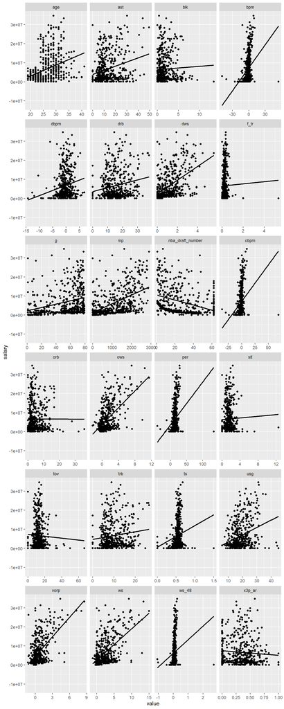

Vemos que por los dibujos no hay ninguna variable que explique mucho el salario. Por eso vamos a hacer lo mismo pero con logaritmos.

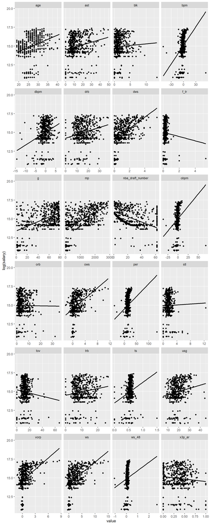

Por los gráficos y los resultado de la práctica anterior vamos a tomar los logaritmos de la variable dependiente salarios ya que son cifras muy elevadas:

## Training set y Testing set

### Matrices del trainig set y del testing set

```
## [1] 363  24
```

- Ahora realizamos la matriz de los valores del testing set, es el 20% de la muestra.

## Elastic Net

Representamos graficamente los resultados de aplicar diferenets alphas. Para alpha = 1 estamos representando el modelo Lasso, podemos ver como van disminuyendo el número de variables. Esto es porque el modelo Lasso hace que klos coeficintes de algunas variables sean 0, lo que hace que desaparezcan.

Pra alpha = 0 ese representa un modelo Ridge, vemos que no desaparece ningua variable. El modelo Ridge acerca los coeficientes a 0, pero nunca los omite por lo que no disminuye el número de variables.

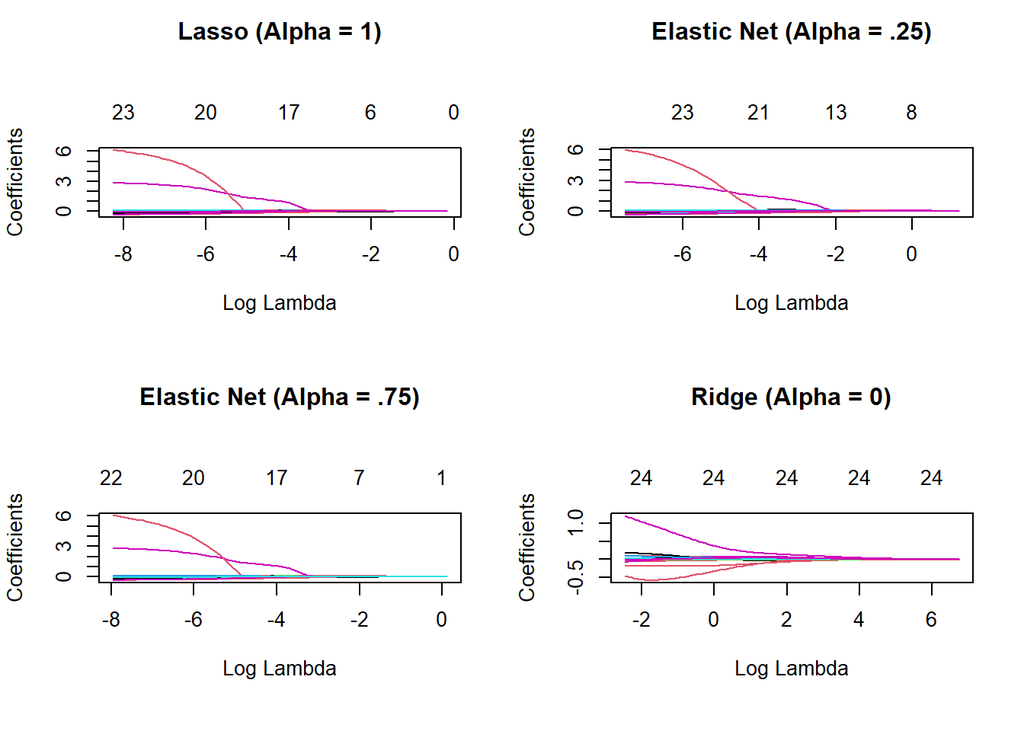

### Tunning Elastic net:

Creamos la estructura de la tabla que nos va a perminrtuirs visulaizar los errores para cada alpha(de 0 a 1, entramos de 0.1)

| alpha | mse_min | mse_1se | lambda_min | lambda_1se |
| --- | --- | --- | --- | --- |
| 0.0 | NA | NA | NA | NA |
| 0.1 | NA | NA | NA | NA |
| 0.2 | NA | NA | NA | NA |
| 0.3 | NA | NA | NA | NA |
| 0.4 | NA | NA | NA | NA |
| 0.5 | NA | NA | NA | NA |
| 0.6 | NA | NA | NA | NA |
| 0.7 | NA | NA | NA | NA |
| 0.8 | NA | NA | NA | NA |
| 0.9 | NA | NA | NA | NA |

[output cut: 1 more lines]

Construimos la tabla que nos permita seleccionar para cada alpha el mejor Lambda. Hay que eleguir el alpha que minimize los errores(mse)

| alpha | mse_min | mse_1se | lambda_min | lambda_1se |
| --- | --- | --- | --- | --- |
| 0.0 | 1.140259 | 1.265221 | 0.102678014 | 1.5247359 |
| 0.1 | 1.127723 | 1.248692 | 0.002603262 | 1.1009827 |
| 0.2 | 1.114025 | 1.202015 | 0.217125128 | 0.6630688 |
| 0.3 | 1.102848 | 1.200970 | 0.158863040 | 0.5324458 |
| 0.4 | 1.096140 | 1.196857 | 0.130763993 | 0.4382689 |
| 0.5 | 1.091827 | 1.180555 | 0.114810656 | 0.3506152 |
| 0.6 | 1.087671 | 1.186293 | 0.095675547 | 0.3206664 |
| 0.7 | 1.084197 | 1.176344 | 0.082007612 | 0.2748569 |
| 0.8 | 1.081748 | 1.168321 | 0.078752846 | 0.2404998 |
| 0.9 | 1.080428 | 1.179981 | 0.070002530 | 0.2346207 |

[output cut: 1 more lines]

Representamos graficamente los errores, eligiremos el modelo más sencillo dentro de los errores mínimos

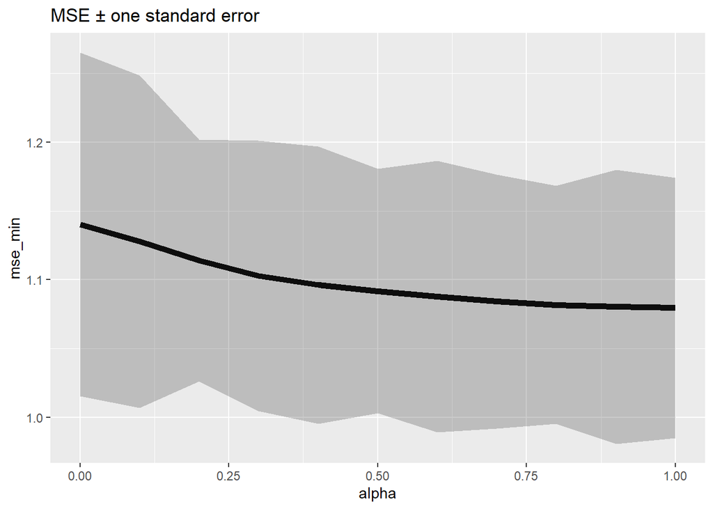

Dado el criterio de selección de mínimos errores y visualizandolo en el gráfico, en este caso seleccionaremos el modelo Lasso. es capaz de realizar una predicción con los errores mínimos con un modelo más sencillo, ya que elimina variables.

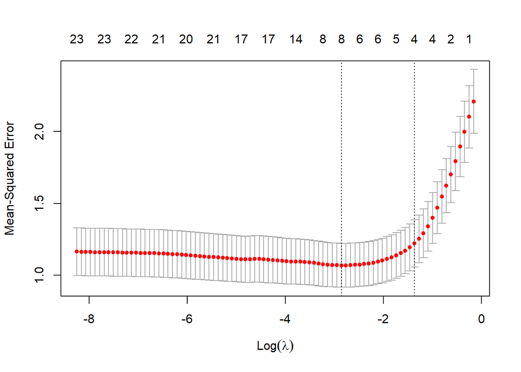

Con este gráfico observamos que el mínimo error see encutra utilizando entre 8 y 4 variables por lo que ese será el modelo que utilicemos

## Predicción

Error mínimo aplicando Lasso:

```
## [1] 1.090203
```

Media del error aplicando Lasso, diferencia entre valores reales y valores de Predicción:

```
## [1] 1.193445
```

Error mínimo con Alpha = 0.2

```
## [1] 1.09456
```

Media del error de Predicción Alpha = 0.2

```
## [1] 1.262848
```